# Composition Across Decades, OPIHI Dataset

Author

Fabiola Gonzalez Zamora

### Making a Heat Map

**Composition Across 2 Decades**

- The OPIHI dataset records 7108 quadrats at 41 sites across 13 survey years, scored by point-intercept
- Figure 1 shows the twelve most abundant taxa, as mean percent cover per quadrat, pooled across every site in each year.
- Two taxa dominate throughout:
  - `Turf algae` account for 30.6% of all recorded cover and `Padina` for 16.1%
  - `Crustose coralline` algae are a distant third at 7.0%, and the remaining 204 taxa divide what is left

```r
library(tidyverse)
library(janitor)
library(here)
library(stringi)
library(plotly)
```

#### Computing Means for Composition Heat Map

- How the means are computed: taxon absent from a quadrat generates no row in the raw data, so the records average about 3.3 taxa per quadrat out of 207 possible.
- Taking a mean over the rows as given would answer “mean cover when present”, which for a patchy species is a very different number from mean cover
- Every figure here therefore completes the taxon-by-quadrat grid first, so an absence is counted as a genuine zero

#### Gaps in Surveys

- No surveys were carried out between 2009 and 2015, or 2021 and 2023
- Axis categorical, so years are omitted rather than left as empty columns

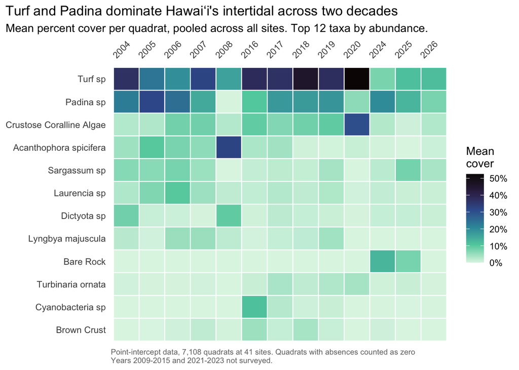

Figure 1: Twelve most abundant taxa, as mean percent cover per quadrat, pooled across every site in each year.

```r
raw <- read_csv(here("Outputs", "clean_master_sheet_percent_cover.csv"),
                show_col_types = FALSE)

# The below below columns together identify ONE quadrat observation
# Verified against the data: these give 7,108 units, every one summing to exactly 100%

quad_keys <- c("date", "site_key", "transect_id", "quadrat_id", "position")

master <- read_csv(here("Outputs", "clean_master_sheet_percent_cover.csv"),
                   show_col_types = FALSE) |>
  mutate(
    date = if (inherits(date, "Date")) date
           else as_date(parse_date_time(date, orders = c("mdy", "ymd"))),
    year = year(date)
  )

stopifnot(!any(is.na(master$year)))

# Rank taxa by total cover across the whole dataset. Summing raw percent_cover
# Absent rows contribute nothing to a sum, so the ranking is unaffected. It is only MEANS that need the zeros made explicit.

top_taxa <- master |>
  group_by(taxon_key) |>
  summarise(total = sum(percent_cover, na.rm = TRUE), .groups = "drop") |>
  slice_max(total, n = 12) |>
  pull(taxon_key)

taxon_year <- master |>
  filter(taxon_key %in% top_taxa) |>
  select(all_of(quad_keys), year, taxon_key, percent_cover) |>
  # Complete within the filtered set - absences become zeros
  # 23,356 rows over 7,108 quadrats is ~3.3 taxa per quadrat out of 207.
  # Without it, mean(percent_cover) = "mean cover WHEN PRESENT",
  # For patchy species is a completely different result
  # nesting() keeps only the quadrat x year combinations that really exist,
  # rather than crossing every column with every other
  complete(nesting(!!!syms(c(quad_keys, "year"))), taxon_key,
           fill = list(percent_cover = 0)) |>
  group_by(year, taxon_key) |>
  summarise(
    mean_cover = mean(percent_cover),
    n_quadrats = n(),
    .groups = "drop"
  ) |>
  # Order taxa by overall abundance so the axis isn't alphabetical
  # Averages each taxon's yearly means to get one sort value per taxon
  mutate(taxon_key = fct_reorder(taxon_key, mean_cover, .fun = mean))

cover_by_taxa_plot <- ggplot(taxon_year, aes(x = factor(year), y = taxon_key, fill = mean_cover)) +
  geom_tile(colour = "white", linewidth = 0.4) +
  # Sequential single hue: lightness rises monotonically with cover, so the
  # reader can tell which end means "more"
  scale_fill_viridis_c(option = "mako", direction = -1,
                       labels = scales::label_number(suffix = "%"),
                       name = "Mean\ncover") +
  scale_x_discrete(position = "top") +
  labs(
    title = "Turf and Padina dominate Hawaiʻi's intertidal across two decades",
    subtitle = "Mean percent cover per quadrat, pooled across all sites. Top 12 taxa by abundance.",
    x = NULL, y = NULL,
    caption = "Point-intercept data, 7,108 quadrats at 41 sites. Quadrats with absences counted as zero\nYears 2009-2015 and 2021-2023 not surveyed."
  ) +
  theme_minimal(base_size = 11) +
  theme(
    panel.grid = element_blank(), # gridlines add nothing behind tiles
    axis.text.x = element_text(angle = 45, hjust = 1),
    plot.title.position = "plot",
    plot.caption = element_text(hjust = 0, colour = "grey45", size = 7.5)
  )

cover_by_taxa_plot
```

### Grouping and Plotting Functions

1. `group_summary()` takes the master sheet and a group name and returns one row per taxon per year. It does three things in a fixed order: identify the most abundant taxa within that group, complete the taxon-by-quadrat grid so absences become zeros, then average. The order matters more than it looks.
2. `group_heatmap()` takes the same arguments and returns a ggplot. Keeping it separate from `group_summary()` means the summarized numbers can be inspected, exported or tested without drawing anything, and the same summary feeds both the static figure and the interactive one.
3. `make_matrix()` exists because plotly will not accept long data for a heat map; it needs a matrix of values with vectors for the row and column labels. `pivot_wider()` names columns in order of first appearance rather than numerically, which would silently produce a chart with its years out of sequence.
4. `to_colorscale()` is a three-line adapter converting an R palette into plotly’s [position, color] format, so the interactive figure uses the same `mako` palette as the static ones.

```r
# case_when() evals top to bottom, stops at the first TRUE
# ORDER IS THE LOGIC here
# Every branch below sits where it does for a reason

draft_groups <- master |>
  distinct(taxon_key) |>
  mutate(functional_group = case_when(

    # Turf first, as its own category - it alone is 30.6% of all cover
    # Kept separated so that algal composition is clearer
    str_detect(taxon_key, regex("\\bturf\\b", ignore_case = TRUE)) ~ "Turf",

    # \\bsand\\b so it cannot match inside "Cellana sandwicensis"
    str_detect(taxon_key, regex("bare rock|^rock$|\\bsand\\b|rubble|pebble|limestone|^hole$|basalt|sediment", ignore_case = TRUE)) ~ "Substrate",

    str_detect(taxon_key, regex("cyanobacteria|lyngbya|symploca", ignore_case = TRUE)) ~ "Cyanobacteria",

    # Crustose coralline algae -> Algae. Must sit ABOVE the coral
    # Otherwise "Coralline" gets caught by "coral"
    str_detect(taxon_key, regex("crustose coralline", ignore_case = TRUE)) ~ "Algae",

    # Same reasoning "Articallate Corraline" might be caught in coral
    str_detect(taxon_key, regex("articulated coralline|^jania|galaxaura|halimeda|bornetella|neomeris|liagora|dichotomaria", ignore_case = TRUE)) ~ "Calcified algae",

    str_detect(taxon_key, regex("coral|porites|montipora|pocillopora", ignore_case = TRUE)) ~ "Coral",

    str_detect(taxon_key, regex("echinometra|urchin|colobocentrotus|cucumber|actinopyga|holothuria|sea star", ignore_case = TRUE)) ~ "Echinoderm",

    # cellana, limpet and opihi live here - they are gastropods
    str_detect(taxon_key, regex("snail|nerita|littorar|littorina|siphonaria|dendropoma|isognomon|thylacodes|morula|brachidontes|haminoea|serpulorbis|mussel|cellana|limpet|opihi", ignore_case = TRUE)) ~ "Mollusc",

    str_detect(taxon_key, regex("barnacle|crab|grapsus|polychaete|anthopleura|anemone|hydroid|pennaria|sponge", ignore_case = TRUE)) ~ "Other invertebrate",

    # \\bcrust\\b with boundaries, so "tenuicrustatus" not caught
    str_detect(taxon_key, regex("unknown|\\bcrust\\b", ignore_case = TRUE)) ~ "Unresolved",

    # Catch-all. Most of the 207 taxa are algae
    # The majority case and goes last by design
    TRUE ~ "Algae"
  ))

count(draft_groups, functional_group, sort = TRUE)
```

```
# A tibble: 10 × 2
   functional_group       n
   <chr>              <int>
 1 Algae                124
 2 Mollusc               20
 3 Echinoderm            14
 4 Calcified algae       11
 5 Coral                  8
 6 Other invertebrate     8
 7 Substrate              8
 8 Unresolved             8
 9 Cyanobacteria          5
10 Turf                   1
```

```r
# Export WITH total abundance, so review effort goes to the taxa that
# actually move the figures rather than down the alphabet
draft_groups |>
  left_join(master |> group_by(taxon_key) |>
              summarise(total = sum(percent_cover, na.rm = TRUE)), by = "taxon_key") |>
  arrange(functional_group, desc(total)) |>
  write_csv(here("Outputs", "functional_groups_to_review.csv"))
```